# Termproject

Peter Kaiser

12/19/2021

## Introduction

This project began as a full ingatlan.com scrape but it turned into a functional ingatlan.com scrapper. One can give it a search link and the number of pages they want to scrape and it will scrape every property on those pages.

## What it does

The major functions are:

get_one_property which scrapes a property from an ingatlan.com link

get_links_on_page which returns the absolute links from an ingatlan.com search page

get_all_property which does the scraping of the given link and saves down the properties in batches

get_read_property which reads back the csvs to a data frame

get_clean which cleans the data

## Analysis

Here is the structure of the data in a table. I only included the first twenty characters of the description, as they get very long and it would cause issues with the HTML.

```r
df %>%
  mutate(description = substr(description, 1, 20)) %>%
  head() %>%
  kable()
```

X

address

price

area

noroom

description

Ingatlan.állapota

Építés.éve

Komfort

Energiatanúsítvány

Emelet

Épület.szintjei

Lift

Belmagasság

Futés

Légkondicionáló

Rezsiköltség

Akadálymentesített

Fürdo.és.WC

Tájolás

Kilátás

Erkély.mérete

Kertkapcsolatos

Tetotér

Parkolás

Parkolóhely.ára

price_in_cur

nohalfroom

1

14. kerület, Dorozsmai utca

36.50

42

1.5

’ÁRCSÖKKENÉS!XIV., Z

nincs megadva

2001 és 2010 között

nincs megadva

nincs megadva

földszint

6

van

3 m-nél alacsonyabb

házközponti egyedi méréssel

nincs megadva

nincs megadva

igen

nincs megadva

északkelet

udvari

nincs megadva

igen

nem tetotéri

teremgarázs hely

NA

HUF

1

2

V. kerület, Károly körút

59.00

50

1.5

——————–

felújított

1950 elott

összkomfortos

nincs megadva

5

6

van

3 m-nél magasabb

házközponti

van

nincs megadva

igen

egy helyiségben

dél

utcai

nincs megadva

nem

nincs megadva

utca, közterület

NA

HUF

1

3

X. kerület, Gergely utca

74.90

86

3.5

——————–

újszeru

2001 és 2010 között

duplakomfortos

CC

3

4

van

3 m-nél alacsonyabb

házközponti egyedi méréssel

van

nincs megadva

nincs megadva

egy helyiségben

délkelet

udvari

10 m˛

nincs megadva

nincs megadva

önálló garázs - megvásárolható

5 000 000 Ft

HUF

3

4

13. kerület, Szent László út

115.90

114

5.0

——————–

újszeru

2001 és 2010 között

duplakomfortos

nincs megadva

5

5

van

3 m-nél alacsonyabb

házközponti egyedi méréssel

van

nincs megadva

nincs megadva

egy helyiségben

kelet

panorámás

14 m˛

nincs megadva

nem tetotéri

teremgarázs hely - megvásárolható

6 000 000 Ft

HUF

0

5

7. kerület, Izabella utca

27.70

31

1.0

——————–

jó állapotú

nincs megadva

nincs megadva

nincs megadva

1

2

nincs

3 m-nél magasabb

elektromos

nincs

nincs megadva

nem

egy helyiségben

nincs megadva

utcai

nincs megadva

nem

nincs megadva

utca, közterület

NA

HUF

0

6

4. kerület, Újpest

72.79

85

3.0

——————–

nincs megadva

2020

duplakomfortos

nincs megadva

2

4

nincs

nincs megadva

hoszivattyú

nincs megadva

nincs megadva

nincs megadva

külön és egyben is

nincs megadva

kertre néz

31 m˛

nincs megadva

nincs megadva

udvari beálló - megvásárolható

2 500 000 Ft

HUF

0

On the first histogram we can see that the price distribution has it’s majority between 0 and 100, and most of the properties there are rounded to 30 m2, 60 m2, and 90 m2.

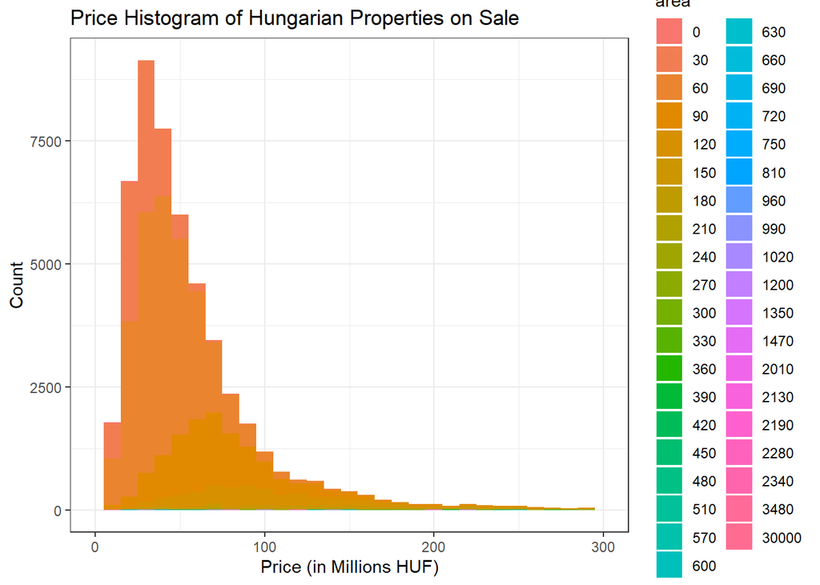

```r
df %>%
  mutate(area = as.factor(round_any(area, 30))) %>%
  ggplot(aes(x = price, fill = area)) +
  geom_histogram(binwidth = 10) +
  xlim(0, 300) +
  labs(
    x = "Price (in Millions HUF)",
    y = "Count",
    title = "Price Histogram of Hungarian Properties on Sale"
  ) +
  theme_bw()
```

On this histogram we can see that the size distribution has it’s majority between 20 and 100, and most of the properties there are rounded to 30 m HUF, 60 m HUF, and 90 m HUF.

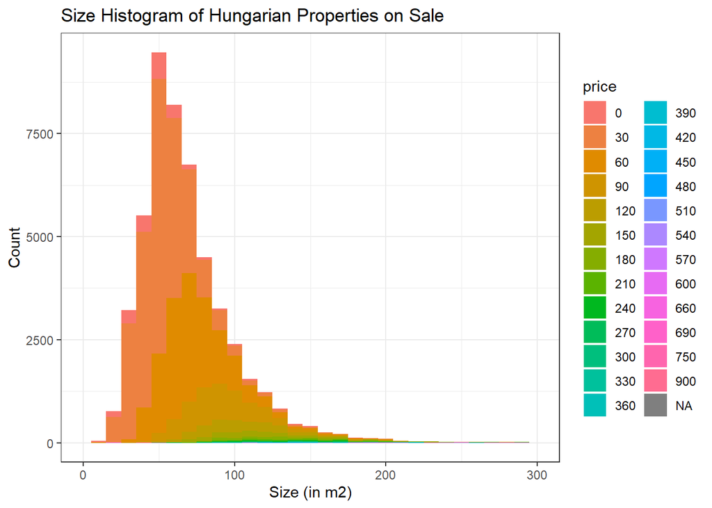

```r
df %>%
  mutate(price = as.factor(round_any(price, 30))) %>%
  ggplot(aes(x = area, fill = price)) +
  geom_histogram(binwidth = 10) +
  xlim(0, 300) +
  labs(
    x = "Size (in m2)",
    y = "Count",
    title = "Size Histogram of Hungarian Properties on Sale"
  ) +
  theme_bw()
```

On this violin plot we can see that the least properties are in “befejezetlen” which means it is not finished and that this category has the widest confidence interval. The average price for the not finished (“befejezetlen”), the newly built (“új építésu”), and the close to newly built (“újszeru”) are pretty similar, with newly built being the highest.

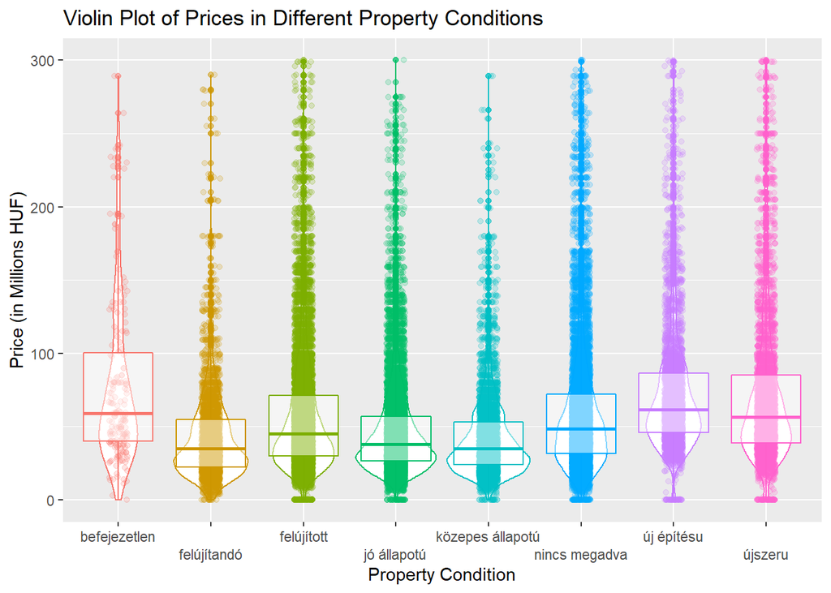

```r
df %>%
  filter(!is.na(Ingatlan.állapota) & !is.na(price)) %>%
  mutate(Ingatlan.állapota = as.factor(Ingatlan.állapota)) %>%
  ggplot(aes(x = Ingatlan.állapota, y = price, colour = Ingatlan.állapota)) +
  ylim(0, 300) +
  geom_violin() +
  geom_jitter(alpha = .2, width = .1) +
  geom_boxplot(alpha = .5) +
  scale_x_discrete(guide = guide_axis(n.dodge = 2)) +
  guides(colour = "none") +
  labs(
    x = "Property Condition",
    y = "Price (in Millions HUF)",
    title = "Violin Plot of Prices in Different Property Conditions"
  )
```

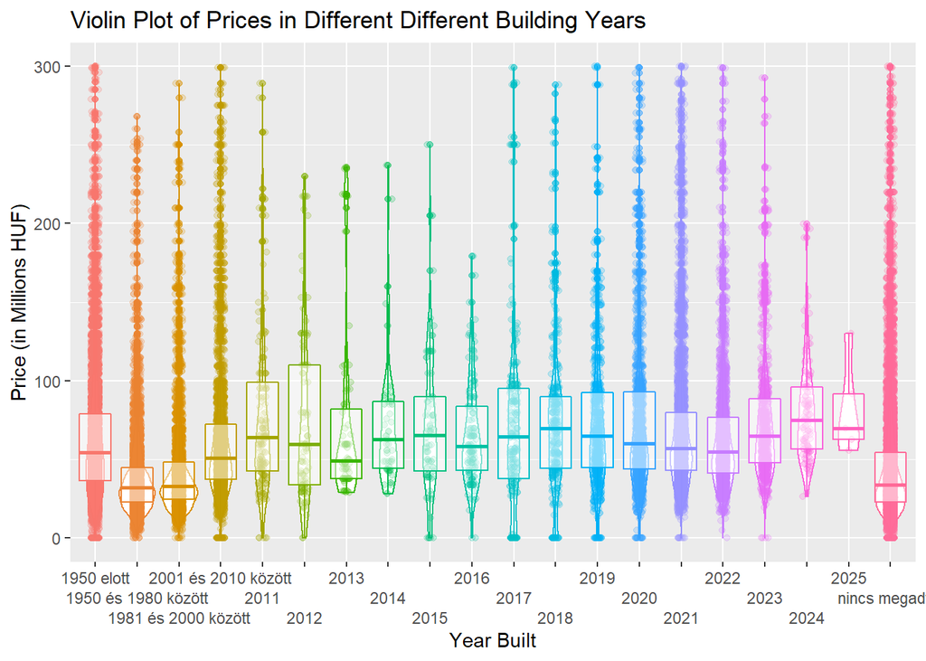

```r
df %>%
  filter(!is.na(Építés.éve) & !is.na(price)) %>%
  mutate(Építés.éve = as.factor(Építés.éve)) %>%
  ggplot(aes(x = Építés.éve, y = price, colour = Építés.éve)) +
  ylim(0, 300) +
  geom_violin() +
  geom_jitter(alpha = .2, width = .1) +
  geom_boxplot(alpha = .5) +
  scale_x_discrete(guide = guide_axis(n.dodge = 3)) +
  guides(colour = "none") +
  labs(
    x = "Year Built",
    y = "Price (in Millions HUF)",
    title = "Violin Plot of Prices in Different Different Building Years"
  )
```